# IA_Actividad_1

# **ACTIVIDAD 1: APLICACIÓN DE TÉCNICAS DE APRENDIZAJE NO SUPERVISADO SOBRE DATOS BIOLÓGICOS**

SAMUEL PINTOS GONZÁLEZ

### Cargamos el working directory y los datos a tratar:

```r
setwd("~/BIOINFORMÁTICA_R/IA/ACTIVIDAD_1")
library(readr)

# Lectura de datos
data.raw <- read.csv('data.csv')
labels.raw<- read.csv('labels.csv')
```

## UMAP

Esta técnica asume que las muestras están distribuidas de manera uniforme en un espacio topológico, el cual puede proyectarse sobre un espacio de menor dimensión. Esta técnica se ha utilizado como primera técnica ya que para este conjunto de datos, se ha observado en las clases teóricas que es un gran método para representar gráficamente la reducción de dimensionalidad. Por esto, es un gran punto de partida para este trabajo, ya que se pueden observar sus ventajas y se pone de manifiesto las desventajas del resto.

### Libererías de UMAP

```r
library(uwot)
```

```r
library(ggplot2)
```

### Rol de los argumentos

x: reduccion de la dimensionalidad n_neighbours: entero que indica el numero de vecinos cercanos n_componentes: entero que determina el tamaño del espacio de salida metric: define la distancia entre puntos min_dist: distancia minima permitida entre puntos local_conectivity: cuantos puntos están conectados “fuertemente” scale: tipos de escalado ret_model: para sacar los resultados del embedding verbose: tiempo hasta que se complete el calculo

### Graficamos con UMAP

```r
# Guardado en un dataframe de los 500 primeros genes
data <- sapply(data.raw[2:501], as.numeric)

umap.results <- umap(data, n_neighbors=0.2 * nrow(data),
                     n_components = 2, min_dist = 0.1, local_connectivity=1,
                     ret_model = TRUE, verbose = TRUE)
```

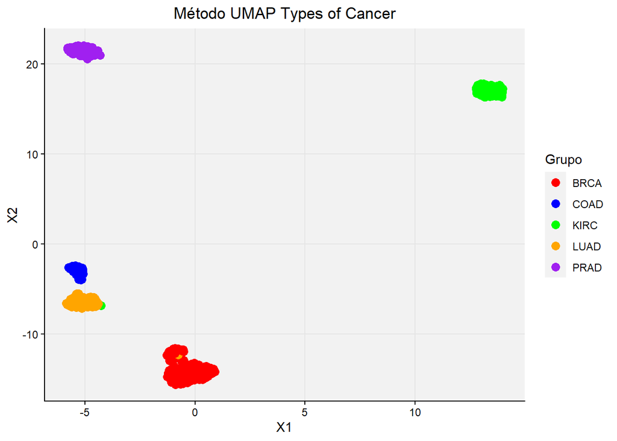

```r
umap.df <- data.frame(umap.results$embedding)

m_dist <- dist(umap.df)

# Graficamos
ggplot(umap.df, aes(x = X1, y = X2, color = labels.raw$Class)) +
  geom_point(size = 3) +
  scale_color_manual(values = c("red", "blue", "green", "orange", "purple")) +
  labs(title = "Método UMAP Types of Cancer", x = "X1", y = "X2", color = "Grupo") +
  theme_classic() +
  theme(panel.grid.major = element_line(color = "gray90"), panel.grid.minor = element_blank(),
        panel.background = element_rect(fill = "gray95"), plot.title=element_text(hjust=0.5))
```

El conjunto de datos se ha separado bastante bien a lo largo de la representación gráfica. Para este conjunto de datos, UMAP es de los mejores, si no el mejor método de aprendizaje no supervisado ya que están bastante distribuidos los datos y se puede ver que hay quizá mayor relación en la expresión de LUAD,COAD y BRCA mientras que la expresión de KIRC y PRAD no está tan estrechamente relacionada con los otros. UMAP es un método muy eficaz a la hora de reducir la dimensionalidad, pero dispone de muchos parámetros tuneables que, al generar muchas combinaciones, dificulta encontrar una proyección óptima.

## T-SNE

T-SNE es una técnica no lineal de exploración y visualización que convierte las distancias entre los puntos de datos en probabilidades condicionales. T-SNE soluciona el problema de hacinamiento que tiene SNE y por ello es por lo que se ha elegido este método frente al otro mencionado. Este no solo optimiza el tiempo de cálculo, sino que proporciona una mejor representación visual de la estructura de un espacio a baja dimensionalidad. Este método además es muy eficiente a la hora de identificar la estructura de los datos.

### Libererías de T-SNE

```r
library(ggplot2)
library(Rtsne)
```

### Rol de los argumentos

X: datos sobre los que reduciremos la dimensionalidad dims: tamaño final del conjunto de datos (mejor <=3) por eficiencia num_threads: hilos a utilizar (procesadores). No hace falta usarlo de momento Variable Y con matriz del t-SNE

### Graficamos con T-SNE

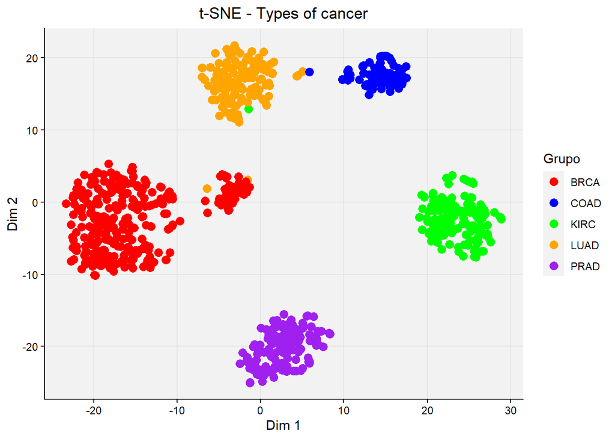

```r
set.seed(1234)
data <- sapply(data.raw[2:501], as.numeric)
tsne <- Rtsne(X=data)
tsne_result <- data.frame(tsne$Y)

ggplot(tsne_result, aes(x = X1, y = X2, color = labels.raw$Class)) +
geom_point(size = 3) +
scale_color_manual(values = c("red", "blue", "green", "orange", "purple")) +
labs(title = "t-SNE - Types of cancer", x = "Dim 1", y = "Dim 2", color = "Grupo") +
theme_classic() +
theme(panel.grid.major = element_line(color = "gray90"), panel.grid.minor = element_blank(),
panel.background = element_rect(fill = "gray95"), plot.title=element_text(hjust=0.5))
```

El conjunto de datos vuelve a estar bastante bien separado y se puede seguir aprenciando esa correlación entre BRCA, COAD y LUAD mientras que KIRC y PRAD parecen tener una expresión menos condicionada por las otras variables. Mientras que es cierto que supera a otras técnicas en el manejo eficiente de datos no lineales (pues captura muy bien las relaciones polinómicas), tiene un cierto componente de azar, es computacionalmente costoso en conjuntos de datos grandes y no es muy eficaz a la hora de reducir un conjunto de datos a más de 3 dimensiones.

## LE

LE (Laplacian Eigenmap) se ha seleccionado intencionalmente previa aplicación de isomap, pues este método trata de preservar la geometría local de los datos, conservando los puntos cercanos en el espacio original una vez estos han sido proyectados en un espacio reducido. LE e ISOMAP se tratarán a partir de ahora en este trabajo como una comparativa entre ellos dentro de la comparativa global de los 4 métodos seleccionados.

### Libererías de LE

```r
library(Rdimtools)
```

```
## ** Version    : 1.1.3       (2026)
```

```
## ** Maintainer : Kisung You  (kisung.you@outlook.com)
```

```
## ** Website    : https://kisungyou.com/Rdimtools/
```

```
## ** Please see 'citation('Rdimtools)' to cite the package.
```

```r
library(ggplot2)
```

### Rol de los argumentos

Definimos los parametros k vecinos mas cercanos como el 20% de la muestra Funcion do.lapeig() X: matriz sobre la que se reducirá la dimensionalidad Ndim: dimensiones de los datos finales type: forma de generar vecinos preprocess: 6 tipos de preprocesamiento weighted: si queremos darle pesos Y: nuevo espacio con menor dimensionalidad eigenvals: vector con los valores propios de las columnas de Y

### Graficamos con LE

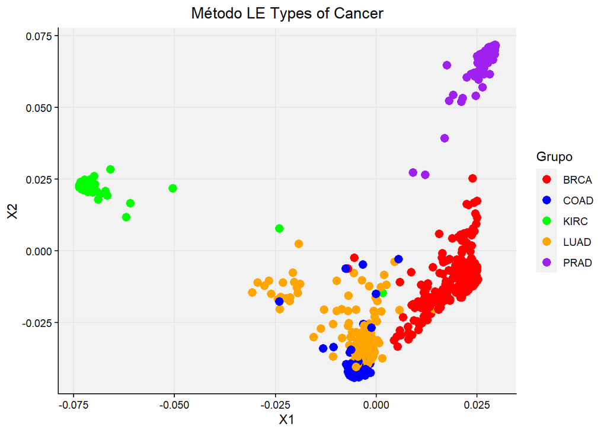

```r
data <- sapply(data.raw[2:501], as.numeric)
le.results <- do.lapeig(data, type=c("proportion", 0.20), weighted=FALSE)
le.df <- data.frame(le.results$Y)
ggplot(le.df, aes(x = X1, y = X2, color = labels.raw$Class)) +
  geom_point(size = 3) +
  scale_color_manual(values = c("red", "blue", "green", "orange", "purple")) +
  labs(title = "Método LE Types of Cancer", x = "X1", y = "X2", color = "Grupo") +
  theme_classic() +
  theme(panel.grid.major = element_line(color = "gray90"), panel.grid.minor = element_blank(),
        panel.background = element_rect(fill = "gray95"), plot.title=element_text(hjust=0.5))
```

Este método, al contrario que los dos primeros, no es muy efectivo para este conjunto de datos, ya que solo con dos dimensiones no podemos separar del todo los datos. Si utilizáramos 3 dimensiones o más segundamente se separarían todos los datos. Nuevamente podemos ver, como con el resto de métodos, que LUAD, BRCA y COAD son variables muy relacionadas, mientras que KIRC y PRAD son variables que tienen una respresentación no tan correlacionada con el resto de variables. Esta técnica es eficiente para vecindarios dispersos y resistente al ruido y valores atípicos. Sin embargo, es extremadamente sensible a los parámetros que se escogen.

## ISOMAP

Este método, como hemos mencionado previamente, se ha seleccionado para ser un contraste del anterior método, pese a ser ambos pertenecientes al grupo de spectral embedding, utilizando valores propios llamados eigenvectors para llevar a cabo las proyecciones del conjunto de datos de un espacio de alta dimensión a otro de menor dimensión. La clave de esta técnica es mantener la distancia geodésica, la cual es determinada por la propia disposición del conjunto de datos.

### Libererías de ISOMAP

```r
library(RDRToolbox)
library(ggplot2)
```

### Rol de los argumentos

data -> datos (matriz) sobre los que haremos reduccion de dimensionalidad dim -> dimensiones de las columnas del espacio reducido k -> numero de vecinos cercanos a cada punto. A mayor k mayor computacion potResiduals -> devuelve la varianza explicada por las diferentes dimensiones

Si se ha elegido una unica dimension devuelve una matriz Si se ha elegido un vector de dimensiones devolvera una matriz por cada elemento del vector

### Graficamos con ISOMAP

```
## Computing distance matrix ... done
## Building graph with shortest paths (using 15 nearest neighbours) ... done
## Computing low dimensional embedding ... done
## number of samples: 801
## reduction from 500 to 12345678910 dimensions
## number of connected components in graph: 1
```

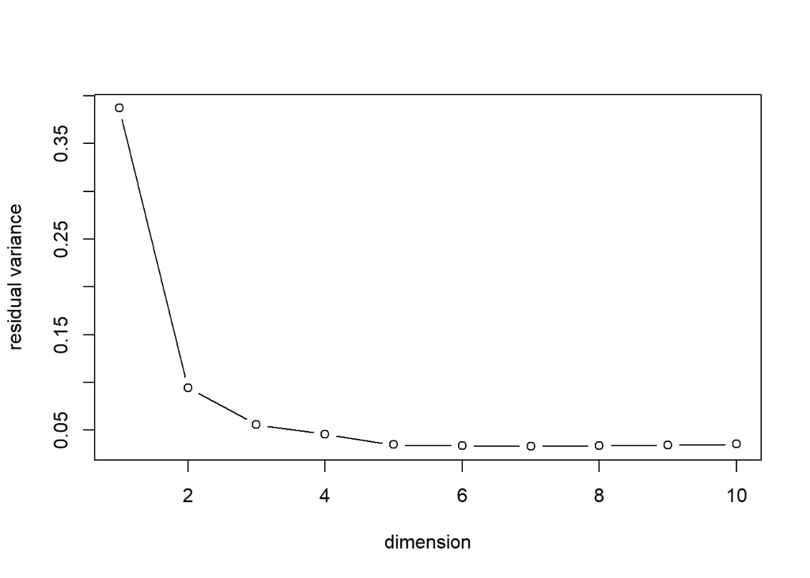

```r
data <- sapply(data.raw[2:501], as.numeric) #no ponemos dataframe!

# Calculamos isomap de 1 a 10 dimensiones y con 5 vecinos (y 30?)
isomap.results = Isomap(data=data, dims=1:10, k=15, plotResiduals=TRUE)
```

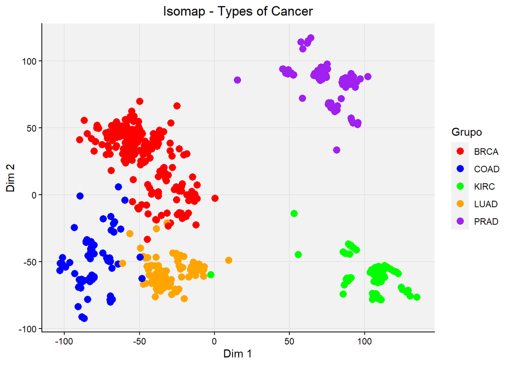

```r
# Dataframe con los puntos que queremos dibujar en el plano 2D

isomap.df <- data.frame(isomap.results$dim2)

ggplot(isomap.df, aes(x = X1, y = X2, color = labels.raw$Class)) +
  geom_point(size = 3) +
  scale_color_manual(values = c("red", "blue", "green", "orange", "purple")) +
  labs(title = "Isomap - Types of Cancer", x = 'Dim 1', y = 'Dim 2', color = "Grupo") +
  theme_classic() +
  theme(panel.grid.major = element_line(color = "gray90"), panel.grid.minor = element_blank(),
        panel.background = element_rect(fill = "gray95"), plot.title=element_text(hjust=0.5))
```

Este método es mejor que el anterior (LE) pero sigue siendo peor que los dos primeros (UMAP y T-SNE). Las variables se separan dejando ver, una última vez, que KIRC y PRAD son variables mucho más separadas y que guardan menos relación con las demás. A su vez, LUAD, COAD y BRCA guardan cierta correlación entre ellas al estar más juntas en el gráfico. Es un método muy eficaz para conjuntos de datos cuyas variables mantienen relaciones no lineales, aunque puede no funcionar con precisión si no existe una suficiente densidad de puntos en el espacio de alta dimensión. Además, una de sus limitaciones es que es muy difñicil encontrar el parámetro k correcto.

## **CONCLUSIONES**

Estos 4 métodos, cada uno con su diferente resultado y representación gráfica, coinciden en el resultado que se puede interpretar, bien es cierto que unos de forma más clara que otros. Podemos ver que KIRC y PRAD son variables que guardan menos relación con las demás, mientras que LUAD, COAD y BRCA guardan cierta correlación. Cada uno con sus ventajas y limitaciones, nos han aportado una conclusión unánime que a continuación se va a discutir. Queda de manifiesto que pese a que unas ofrecen mayor claridad visual, todas apuntan al mismo hecho, por lo que este trabajo no se debe tomar como una ligera comparativa; todos los métodos ayudan a contrastar la interpretación del otro, siendo todos una puesta en común para una interpretación mucho más sólida y veraz.

Esta interpretación además tiene bastante sentido biológico:

- KIRC (Kidney Renal Clear Cell Carcinoma) tiene su origen en células epiteliales, tiene un metabolismo muy particular y su fisiología es muy distinta al resto de los cánceres que se han utilizado en el estudio, por lo que tiene sentido que KIRC esté aislado del resto de variables.
- PRAD (Prostate Adenocarcinoma) tiene su origen en epitelio glandular y es muy dependiente de las señales hormonales, lo que le hace ser distinto al resto de cánceres y estar aislado del resto de variables del estudio.
- LUAD,COAD y BRCA son cánceres que son todos tumores epiteliales del endodermo (derivan del endodermo anterior/medio), comparten vías oncogénicas frecuentes (Notch,Wnt / RAS,RAF,MEk / CCND1,MYC), comparten subtipos moleculares similares y patrones de expresión de genes epiteliales. Es por esto por lo que en el análisis de reducción de dimensionalidad, estos tres tipos de cáncer están mucho más relacionados entre sí que con el resto.